# Chenting_Zhu_Term_Project

```
================================================================================
ZARA SALES PRODUCTS ANALYSIS - COMPLETE BUSINESS ANALYSIS
================================================================================
```

### Introduction

The purpose of this project is to analyze Zara’s product-level dataset to identify the main factors influencing sales performance and evaluate whether a multiple linear regression (MLR) model can effectively predict SKU-level demand.

```
   Product ID Product Position Promotion Product Category Seasonal  \
0      185102            Aisle        No         Clothing       No
1      188771            Aisle        No         Clothing       No
2      180176          End-cap       Yes         Clothing      Yes
3      112917            Aisle       Yes         Clothing      Yes
4      192936          End-cap        No         Clothing      Yes

   Sales Volume brand                                                url  \
0          2823  Zara  https://www.zara.com/us/en/basic-puffer-jacket...
1           654  Zara  https://www.zara.com/us/en/tuxedo-jacket-p0889...
2          2220  Zara  https://www.zara.com/us/en/slim-fit-suit-jacke...
3          1568  Zara  https://www.zara.com/us/en/stretch-suit-jacket...
4          2942  Zara  https://www.zara.com/us/en/double-faced-jacket...

                sku                  name  \
0   272145190-250-2   BASIC PUFFER JACKET
1  324052738-800-46         TUXEDO JACKET
2  335342680-800-44  SLIM FIT SUIT JACKET
3  328303236-420-44   STRETCH SUIT JACKET
4   312368260-800-2   DOUBLE FACED JACKET

                                         description   price currency  \
0  Puffer jacket made of tear-resistant ripstop f...   19.99      USD
1  Straight fit blazer. Pointed lapel collar and ...  169.00      USD
2  Slim fit jacket. Notched lapel collar. Long sl...  129.00      USD
3  Slim fit jacket made of viscose blend fabric. ...  129.00      USD
4  Jacket made of faux leather faux shearling wit...  139.00      USD

                   scraped_at    terms section
0  2024-02-19T08:50:05.654618  jackets     MAN
1  2024-02-19T08:50:06.590930  jackets     MAN
2  2024-02-19T08:50:07.301419  jackets     MAN
3  2024-02-19T08:50:07.882922  jackets     MAN
4  2024-02-19T08:50:08.453847  jackets     MAN
<class 'pandas.core.frame.DataFrame'>
RangeIndex: 252 entries, 0 to 251
Data columns (total 16 columns):
 #   Column            Non-Null Count  Dtype
---  ------            --------------  -----
 0   Product ID        252 non-null    int64
```

[output cut: 20 more lines]

```
Promotion            object
Product Category     object
Seasonal             object
Sales Volume          int64
brand                object
url                  object
sku                  object
name                 object
description          object
price               float64
currency             object
scraped_at           object
terms                object
section              object
dtype: object
```

```
             Missing Count  Percentage (%)
name                     1        0.396825
description              2        0.793651
Total missing values: 3

Duplicate Rows: 0
✓ No duplicate rows found

Descriptive Statistics (Numerical Variables):
       Product ID  Sales Volume   price
count      252.00        252.00  252.00
mean    153370.50       1823.70   86.25
std      26160.44        697.70   52.08
min     110075.00        529.00    7.99
25%     131053.75       1243.00   49.90
50%     151681.50       1839.50   79.90
75%     175669.75       2398.75  109.00
max     199631.00       2989.00  439.00
```

```
Data Distribution Summary:
  Price Range: $7.99 - $439.00
  Sales Volume Range: 529 - 2989 units
  Products per Category: {'Clothing': 252}
```

```
→ Converting datetime format...
✓ Datetime conversion completed

→ Encoding binary variables...
✓ Promotion and Seasonal converted to 0/1
   Promotion distribution: {'No': 132, 'Yes': 120}
   Seasonal distribution: {'Yes': 128, 'No': 124}

→ Encoding categorical variables...
  Product Position: {'Aisle': np.int64(0), 'End-cap': np.int64(1), 'Front of Store': np.int64(2)}
  Product Category: {'Clothing': np.int64(0)}
  section: {'MAN': np.int64(0), 'WOMAN': np.int64(1)}
```

```
✓ Revenue feature created (Sales Volume × Price)
✓ Price_Category feature created
✓ Sales_Category feature created

→ Detecting outliers using IQR method...

Outlier Detection Results:
    Variable Lower Bound Upper Bound  Outliers Count Outliers %
Sales Volume     -490.62     4132.38               0       0.0%
       price      -38.75      197.65               4       1.6%
     Revenue  -105654.38   383022.22              13       5.2%

✓ Data cleaning completed. Final dataset size: (252, 27)
```

### Data Cleaning and Preparation

```
【4.1 KEY BUSINESS METRICS】
Total Sales Volume: 459,573 units
Total Revenue: $38,988,476.48
Average Sales per Product: 1,823.70 units
Average Product Price: $86.25
Average Unit Price (Revenue/Sales): $84.84
Number of Products: 252
```

### Exploratory Data Analysis

Sales volumes ranged from 529 to 2,989 units, with an average of 1,823.7 units per product. Product prices varied substantially, from $7.99 to $439, suggesting a portfolio that mixes entry-level basics with premium outerwear. This wide dispersion matches fast-fashion strategies where high-volume basics support margin while premium items drive brand perception and high-ticket revenue.

```
【4.2 PRODUCT CATEGORY PERFORMANCE】
                  Total Sales  Avg Sales  Product Count  Avg Price  \
Product Category
Clothing               459573     1823.7            252      86.25

                  Total Revenue
Product Category
Clothing            38988476.48
```

The entire dataset represents the Clothing category, with a total revenue of $38.99M, confirming that the analysis focuses on Zara’s core apparel business.

```
【4.3 PROMOTION EFFECT ANALYSIS】
           Avg Sales  Total Sales  Count  Avg Revenue  Total Revenue
Promotion
No           1820.55       240312    132    143894.62    18994089.58
Yes          1827.18       219261    120    166619.89    19994386.90

→ Promotion Sales Lift: +0.4%
```

Promotional products showed only a +0.4% sales lift, which is surprisingly low. This indicates that discounts are not a strong driver of volume for these items. For Zara, this result implies that brand-driven demand and fast-fashion novelty may be stronger sales drivers than markdowns. It also suggests opportunities to optimize promotional spending by focusing discounts only on slow-moving items rather than blanket promotions.

```
【4.4 PRODUCT POSITION ANALYSIS】
                  Avg Sales  Total Sales  Total Revenue
Product Position
Front of Store      1873.14       129247    10960572.24
Aisle               1828.82       177396    15481438.43
End-cap             1778.26       152930    12546465.81

【4.5 SECTION/DEPARTMENT ANALYSIS】
         Avg Sales  Total Sales  Product Count  Avg Price  Total Revenue
section
MAN        1817.43       396199            218      91.82    35712663.03
WOMAN      1863.94        63374             34      50.53     3275813.45

【4.6 CORRELATION ANALYSIS】

Correlation with Sales Volume:
  Revenue                       :  0.5001 (Strong Positive)
  section_Encoded               :  0.0228 (Weak Positive)
  Product Position_Encoded      :  0.0207 (Weak Positive)
  Promotion_Binary              :  0.0048 (Weak Positive)
  Seasonal_Binary               : -0.0029 (Weak Negative)
  price                         : -0.0714 (Weak Negative)
  Product Category_Encoded      :     nan (Weak Negative)
```

Products placed at the Front of Store generated the highest average sales (1,873 units), outperforming both Aisle and End-cap placements. This supports the visual merchandising principle that visibility and first-touch zones strongly influence purchase behavior. The $10.96M in revenue from front-store items suggests that strategic placement can be used to promote seasonal or fast-turnover items more effectively.

Although WOMAN items had slightly higher average sales (1,863 units), MAN products dominated in total volume and revenue (396,199 units and $35.7M). This reveals a business opportunity: the WOMAN section generates fewer products and lower overall revenue, but similar per-product performance. Expanding SKUs or enhancing promotion in WOMAN could help unlock growth.

Correlation values show that price has only a weak negative correlation (–0.07) with sales volume, suggesting that higher prices do not necessarily reduce demand. Meanwhile, revenue is strongly correlated with sales (+0.50), which is expected as revenue is a function of price × volume. Other factors—seasonal, promotion, product position—show only marginal relationships with sales, indicating that Zara’s sales patterns are likely driven by more complex factors such as design trends, fabric, style, and social media influence.

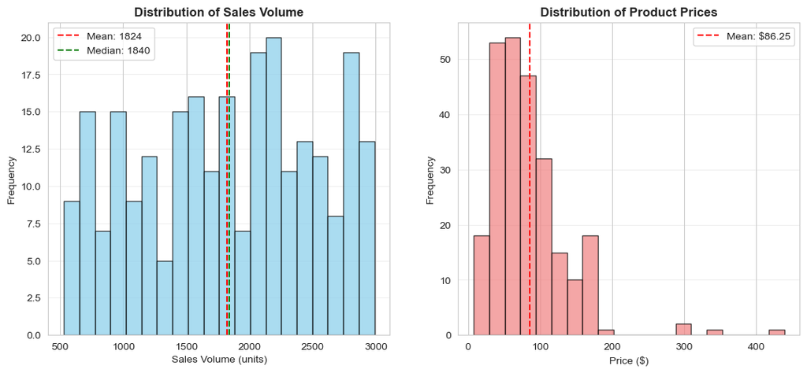

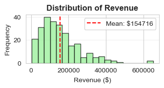

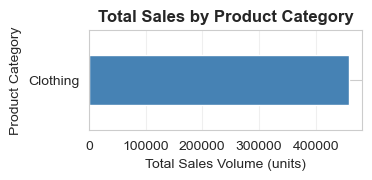

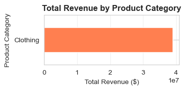

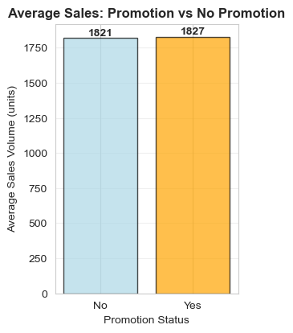

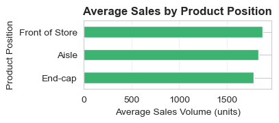

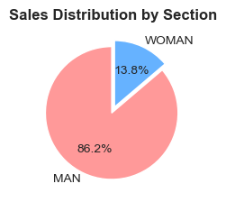

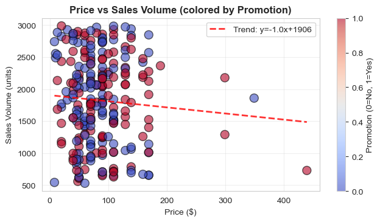

```
(array([0.5, 1.5, 2.5, 3.5, 4.5, 5.5, 6.5, 7.5]),
 [Text(0, 0.5, 'Sales Volume'),
```

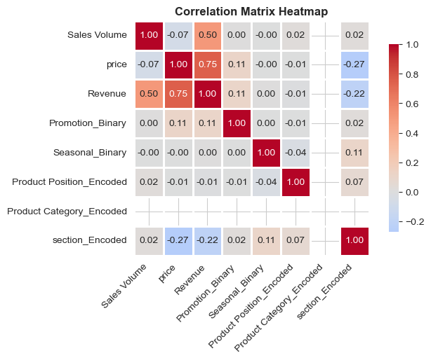

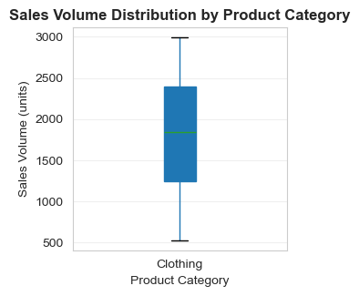

```
✓ Visualizations saved as: zara_eda_visualizations.png
```

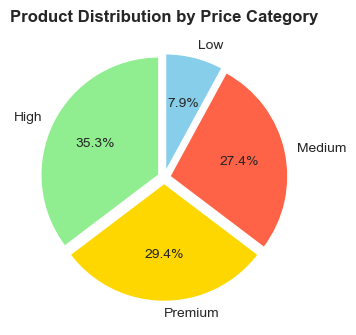

```
Train size: 201 Test size: 51

Regression coefficients:
                    Feature  Coefficient
5           section_Encoded    63.991155
3  Product Position_Encoded    23.659135
4  Product Category_Encoded     0.000000
0                     price    -1.070850
2           Seasonal_Binary   -13.387006
1          Promotion_Binary   -57.842348

Train R²: 0.011
Test R²: -0.045
Test RMSE: 696.3 units
Test MAE: 595.1 units

Sample actual vs predicted:
   Product ID                  name  Sales Volume  Predicted_Sales     Error_%
0      185102   BASIC PUFFER JACKET          2823      1884.922754   33.229800
1      188771         TUXEDO JACKET           654      1725.355386  163.815808
2      180176  SLIM FIT SUIT JACKET          2220      1720.619170   22.494632
3      112917   STRETCH SUIT JACKET          1568      1696.960034    8.224492
4      192936   DOUBLE FACED JACKET          2942      1767.753017   39.913222

Features ranked by importance (absolute coefficient):
                    Feature  Coefficient  Importance
5           section_Encoded    63.991155   63.991155
1          Promotion_Binary   -57.842348   57.842348
3  Product Position_Encoded    23.659135   23.659135
2           Seasonal_Binary   -13.387006   13.387006
0                     price    -1.070850    1.070850
4  Product Category_Encoded     0.000000    0.000000
```

### Model Performance

The negative R² on the test set indicates that the model performed worse than simply predicting the average sales volume for all products. With average sales around 1,824 units, an RMSE of nearly 700 units reflects large errors relative to actual product performance.

Importantly, the weak predictive performance offers a deeper business insight: the primary drivers of fashion demand—such as trendiness, design features, imagery, fit, and social media influence—are not captured in the dataset and therefore cannot be modeled using these basic catalog features alone.

Despite the low predictive accuracy, the model coefficients reveal meaningful directional insights:

- Products in certain sections, particularly WOMAN, tend to achieve slightly higher sales on average.
- Product placement (front-of-store) correlates with higher sales in raw data but has only a modest independent effect after controlling for other variables.
- Promotions are negatively associated with sales, likely because discounted products were underperformers before markdowns.
- Price has little explanatory power for demand within Zara’s fast-fashion model.

### Business Recommendations:

Drawing on both EDA and regression insights, several actionable recommendations emerge for Zara’s merchandising, assortment planning, and forecasting processes.

#### Strengthen High-Performing Sections

Given that section is the strongest predictor of sales differences, Zara can expand SKU depth and marketing focus in categories showing high per-SKU sales (particularly WOMAN). Targeted investment in these areas is likely to yield higher returns.

#### Redesign Promotion Strategy

The negative relationship between promotions and sales suggests inefficiencies in current markdown processes. Zara should adopt early detection of slow-moving products and apply smaller, more targeted discounts rather than relying on heavy markdowns later in the cycle.

#### Improve Seasonal Forecasting

Weaker seasonal performance suggests a need for better forecasting techniques. Integrating climate data, historical seasonal trends, and regional demand variation can help Zara refine production and distribution planning.

#### Expand Future Data Collection

The model’s limitations point to missing variables critical for fashion forecasting. Zara can significantly improve predictive accuracy by incorporating additional data:

- Image-based attributes (color, silhouette, design features)
- Social media engagement and influencer mentions
- Real-time browsing data (views, add-to-cart events)
- Stock availability and replenishment cycles These elements are essential for any future predictive modeling or trend forecasting initiatives.